# GAS simulations: GAS score distributions

Exploratory analysis

Taylor Dunn

2021-06-21

# Motivation

The simulation technique introduced by Urach et al. (2019) returns latent variable goal scores which (in the absence of a treatment effect) will be normally distributed with mean 0 and SD 1:

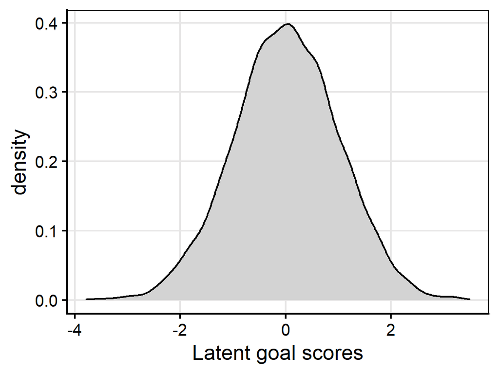

```r
d <- tibble(x_continuous = rnorm(1e4, mean = 0, sd = 1))

p <- d %>%
  ggplot(aes(x_continuous)) +
  geom_density(fill = "lightgrey") +
  labs(x = "Latent goal scores")
p
```

Latent goal scores are then discretized into the 5-point scales according to a set of thresholds. The thresholds proposed by Urach et al. (2019) were equally spaced along along the inverse cumulative normal distribution $\Phi^{-1}$:

$$c_t = \Phi^{-1} (0.2t), \ \ \ \ \ t = 0, \dots, 5$$

Here is how those thresholds look overlaid on the latent variable scale:

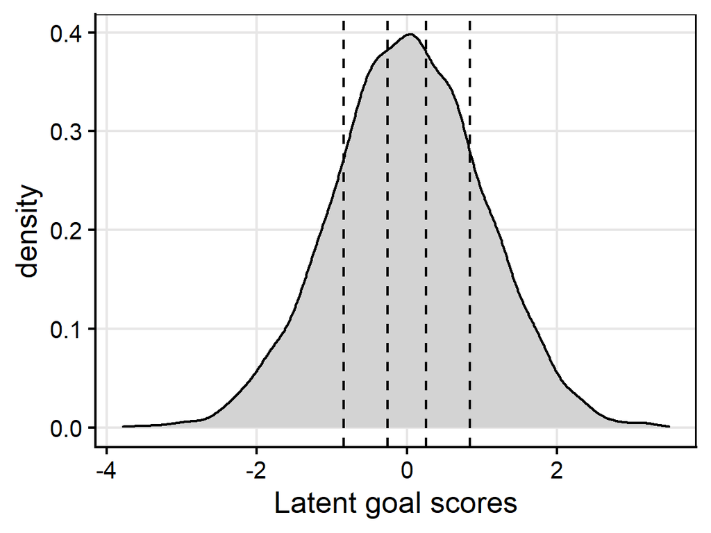

```r
thresh_unif <- qnorm(seq(0, 1, 0.2), mean = 0, sd = 1)

p +
  geom_vline(xintercept = thresh_unif, lty = 2)
```

And this is the resulting distribution of discrete goal scores:

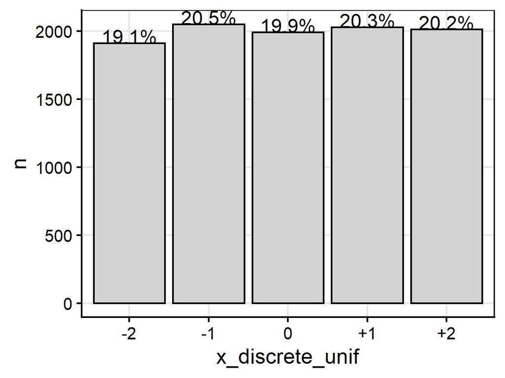

```r
d <- d %>%
  mutate(
    x_discrete_unif = gasr::discretize_from_thresholds(x_continuous,
                                                       thresh_unif),
    x_discrete_unif = factor(x_discrete_unif, levels = -2:2,
                             labels = c("-2", "-1", "0", "+1", "+2"))
  )
d %>%
  count(x_discrete_unif) %>%
  mutate(p = n / sum(n)) %>%
  ggplot(aes(x = x_discrete_unif, y = n)) +
  geom_col(fill = "lightgrey", color = "black") +
  geom_text(aes(label = scales::percent(p, accuracy = 0.1)), vjust = 0) +
  labs("Discrete goal scores (uniform thresholds)")
```

Theses thresholds, on the other hand:

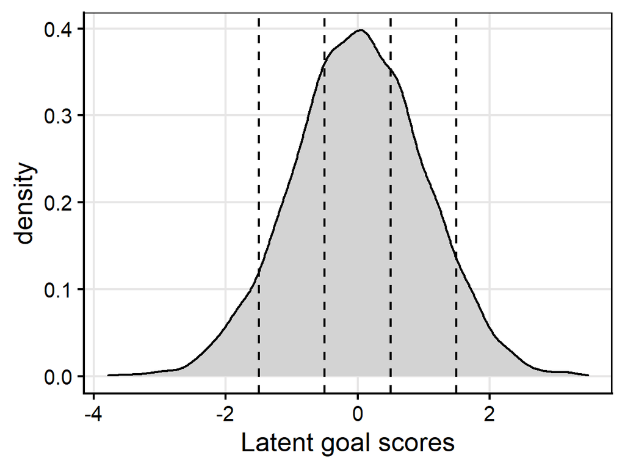

```r
thresh_norm <- gasr::create_thresholds()
p +
  geom_vline(xintercept = thresh_norm, lty = 2)
```

Which produce an approximately normal distribution of 5-point scores:

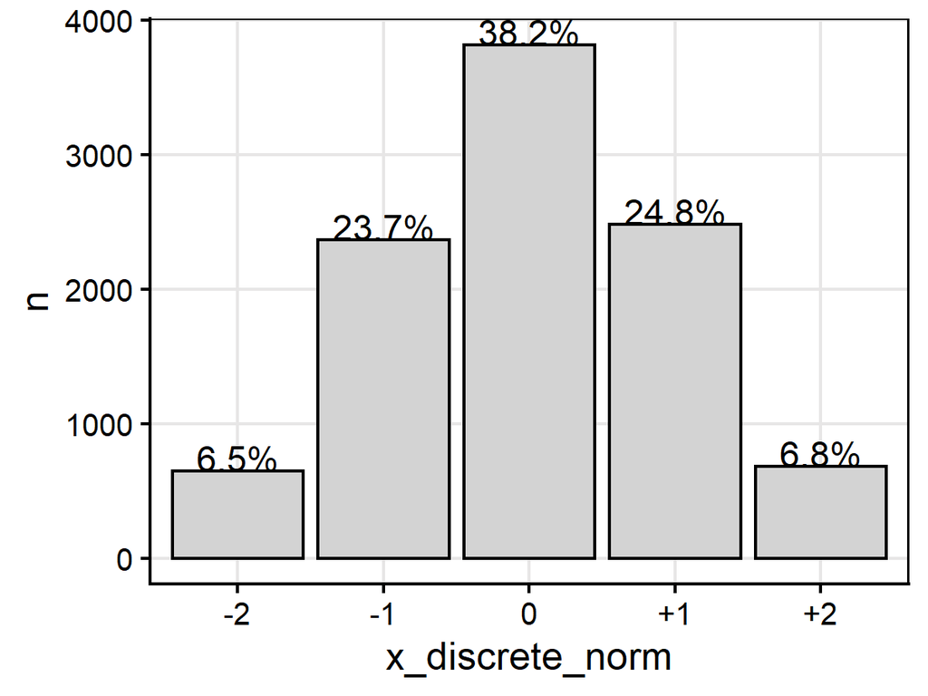

```r
d <- d %>%
  mutate(
    x_discrete_norm = gasr::discretize_from_thresholds(x_continuous,
                                                       thresh_norm),
    x_discrete_norm = factor(x_discrete_norm, levels = -2:2,
                             labels = c("-2", "-1", "0", "+1", "+2"))
  )
d %>%
  count(x_discrete_norm) %>%
  mutate(p = n / sum(n)) %>%
  ggplot(aes(x = x_discrete_norm, y = n)) +
  geom_col(fill = "lightgrey", color = "black") +
  geom_text(aes(label = scales::percent(p, accuracy = 0.1)), vjust = 0) +
  labs("Discrete goal scores (normal thresholds)")
```

How does the difference in score distributions affect the power to detect a treatment effect, and the estimated size of that treatment effect?

# Analysis

Load the data:

```r
#tar_load(sim_data_ttest)
tar_load(sim_data_tscore_power)
tar_load(sim_data_mean_score_power)
tar_load(sim_data_mean_score_perf)
tar_load(sim_data_mean_score_ttest)
tar_load(sim_data_tscore_ttest)
tar_load(sim_data_tscore_effect_size)
```

Pre-process:

```r
sim_data_power <-
  bind_rows(
    "tscore" = sim_data_tscore_power,
    "mean_score" = sim_data_mean_score_power,
    .id = "summary_score"
  ) %>%
  # Add some labels for plotting
  mutate(
    n_subjects_delta = glue("{n_subjects} subjects, delta = {delta}"),
    n_subjects_n_goals = glue("{n_subjects} subjects, ",
                              "{n_goals} goals per subject"),
    n_goals_label = glue("{n_goals} goals per subject"),
    power_label = scales::percent(power, accuracy = 1),
    score_dist_label = factor(score_dist, levels = c("norm", "unif"),
                              labels = c("Normal", "Uniform"))
  )
sim_data_mean_score_perf <-
  sim_data_mean_score_perf %>%
  mutate(
    n_subjects_delta = glue("{n_subjects} subjects, delta = {delta}"),
    n_subjects_n_goals = glue("{n_subjects} subjects, ",
                              "{n_goals} goals per subject"),
    n_goals_label = glue("{n_goals} goals per subject"),
    score_dist_label = factor(score_dist, levels = c("norm", "unif"),
                              labels = c("Normal", "Uniform"))
  )
```

The parameter combinations that were simulated:

```r
sim_data_power %>%
  distinct(n_subjects, delta, n_goals, n_sim) %>%
  gt() %>%
  tab_options(container.height = 300,
              container.overflow.y = TRUE)
```

| n_subjects | delta | n_goals | n_sim |
| --- | --- | --- | --- |
| 40 | 0.3 | 1 | 1000 |
| 40 | 0.3 | 2 | 1000 |
| 40 | 0.3 | 3 | 1000 |
| 40 | 0.3 | 4 | 1000 |
| 40 | 0.3 | 5 | 1000 |
| 40 | 0.5 | 1 | 1000 |
| 40 | 0.5 | 2 | 1000 |
| 40 | 0.5 | 3 | 1000 |
| 40 | 0.5 | 4 | 1000 |
| 40 | 0.5 | 5 | 1000 |
| 40 | 0.7 | 1 | 1000 |
| 40 | 0.7 | 2 | 1000 |
| 40 | 0.7 | 3 | 1000 |
| 40 | 0.7 | 4 | 1000 |
| 40 | 0.7 | 5 | 1000 |
| 40 | 0.9 | 1 | 1000 |
| 40 | 0.9 | 2 | 1000 |
| 40 | 0.9 | 3 | 1000 |
| 40 | 0.9 | 4 | 1000 |
| 40 | 0.9 | 5 | 1000 |
| 40 | 1.1 | 1 | 1000 |
| 40 | 1.1 | 2 | 1000 |
| 40 | 1.1 | 3 | 1000 |
| 40 | 1.1 | 4 | 1000 |
| 40 | 1.1 | 5 | 1000 |
| 60 | 0.3 | 1 | 1000 |
| 60 | 0.3 | 2 | 1000 |
| 60 | 0.3 | 3 | 1000 |
| 60 | 0.3 | 4 | 1000 |
| 60 | 0.3 | 5 | 1000 |
| 60 | 0.5 | 1 | 1000 |
| 60 | 0.5 | 2 | 1000 |
| 60 | 0.5 | 3 | 1000 |
| 60 | 0.5 | 4 | 1000 |
| 60 | 0.5 | 5 | 1000 |
| 60 | 0.7 | 1 | 1000 |
| 60 | 0.7 | 2 | 1000 |
| 60 | 0.7 | 3 | 1000 |
| 60 | 0.7 | 4 | 1000 |
| 60 | 0.7 | 5 | 1000 |
| 60 | 0.9 | 1 | 1000 |
| 60 | 0.9 | 2 | 1000 |
| 60 | 0.9 | 3 | 1000 |
| 60 | 0.9 | 4 | 1000 |
| 60 | 0.9 | 5 | 1000 |
| 60 | 1.1 | 1 | 1000 |
| 60 | 1.1 | 2 | 1000 |
| 60 | 1.1 | 3 | 1000 |
| 60 | 1.1 | 4 | 1000 |
| 60 | 1.1 | 5 | 1000 |
| 80 | 0.3 | 1 | 1000 |
| 80 | 0.3 | 2 | 1000 |
| 80 | 0.3 | 3 | 1000 |
| 80 | 0.3 | 4 | 1000 |
| 80 | 0.3 | 5 | 1000 |
| 80 | 0.5 | 1 | 1000 |
| 80 | 0.5 | 2 | 1000 |
| 80 | 0.5 | 3 | 1000 |
| 80 | 0.5 | 4 | 1000 |
| 80 | 0.5 | 5 | 1000 |
| 80 | 0.7 | 1 | 1000 |
| 80 | 0.7 | 2 | 1000 |
| 80 | 0.7 | 3 | 1000 |
| 80 | 0.7 | 4 | 1000 |
| 80 | 0.7 | 5 | 1000 |
| 80 | 0.9 | 1 | 1000 |
| 80 | 0.9 | 2 | 1000 |
| 80 | 0.9 | 3 | 1000 |
| 80 | 0.9 | 4 | 1000 |
| 80 | 0.9 | 5 | 1000 |
| 80 | 1.1 | 1 | 1000 |
| 80 | 1.1 | 2 | 1000 |
| 80 | 1.1 | 3 | 1000 |
| 80 | 1.1 | 4 | 1000 |
| 80 | 1.1 | 5 | 1000 |

Visualize the power for 40 subjects for the T-score:

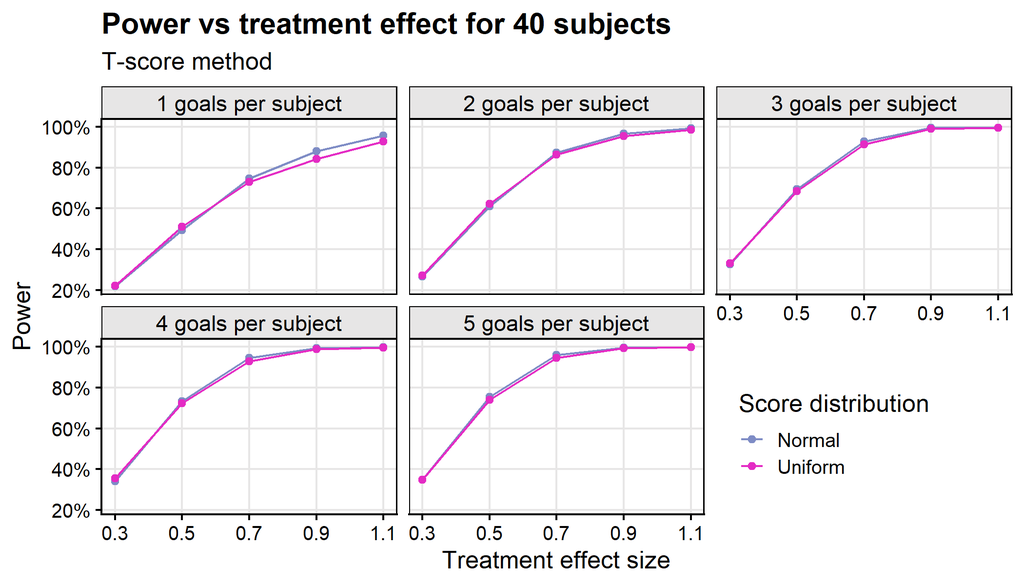

```r
sim_data_power %>%
  filter(n_subjects == 40, summary_score == "tscore") %>%
  ggplot(aes(x = delta, y = power, color = score_dist_label)) +
  geom_line() +
  geom_point() +
  facet_wrap(~n_goals_label) +
  scale_x_continuous("Treatment effect size",
                     breaks = c(0.3, 0.5, 0.7, 0.9, 1.1)) +
  scale_y_continuous("Power", labels = scales::percent) +
  labs(color = "Score distribution",
       title = "Power vs treatment effect for 40 subjects",
       subtitle = "T-score method") +
  theme(legend.position = c(0.7, 0.2))
```

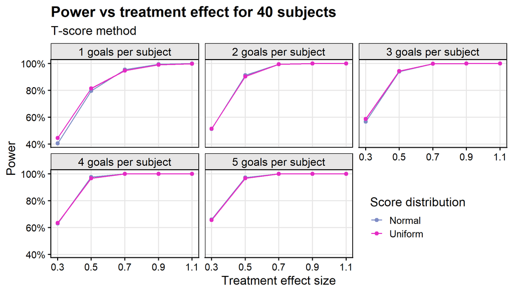

```r
sim_data_power %>%
  filter(n_subjects == 80, summary_score == "tscore") %>%
  ggplot(aes(x = delta, y = power, color = score_dist_label)) +
  geom_line() +
  geom_point() +
  facet_wrap(~n_goals_label) +
  scale_x_continuous("Treatment effect size",
                     breaks = c(0.3, 0.5, 0.7, 0.9, 1.1)) +
  scale_y_continuous("Power", labels = scales::percent) +
  labs(color = "Score distribution",
       title = "Power vs treatment effect for 40 subjects",
       subtitle = "T-score method") +
  theme(legend.position = c(0.7, 0.2))
```

Are there any parameters combinations where there was a large power difference?

```r
sim_data_power %>%
  select(n_subjects, delta, n_goals, score_dist, summary_score, power) %>%
  pivot_wider(names_from = score_dist, values_from = power) %>%
  rename(power_norm = norm, power_unif = unif) %>%
  mutate(
    power_diff = power_norm - power_unif
  ) %>%
  arrange(desc(abs(power_diff))) %>%
  mutate(across(c(power_norm, power_unif, power_diff),
                ~scales::percent(., accuracy = 0.1))) %>%
  gt() %>%
  tab_options(container.height = 300,
              container.overflow.y = TRUE)
```

| n_subjects | delta | n_goals | summary_score | power_norm | power_unif | power_diff |
| --- | --- | --- | --- | --- | --- | --- |
| 80 | 0.3 | 1 | tscore | 40.6% | 44.6% | -4.0% |
| 80 | 0.3 | 1 | mean_score | 40.6% | 44.6% | -4.0% |
| 40 | 0.9 | 1 | tscore | 88.0% | 84.2% | 3.8% |
| 40 | 0.9 | 1 | mean_score | 88.0% | 84.2% | 3.8% |
| 40 | 1.1 | 1 | tscore | 95.7% | 92.9% | 2.8% |
| 40 | 1.1 | 1 | mean_score | 95.7% | 92.9% | 2.8% |
| 80 | 0.3 | 3 | tscore | 56.9% | 58.9% | -2.0% |
| 80 | 0.3 | 3 | mean_score | 56.9% | 58.9% | -2.0% |
| 40 | 0.5 | 1 | tscore | 49.3% | 51.1% | -1.8% |
| 40 | 0.5 | 1 | mean_score | 49.3% | 51.1% | -1.8% |
| 80 | 0.5 | 1 | tscore | 79.7% | 81.5% | -1.8% |
| 80 | 0.5 | 1 | mean_score | 79.7% | 81.5% | -1.8% |
| 40 | 0.7 | 1 | tscore | 74.6% | 72.9% | 1.7% |
| 40 | 0.7 | 1 | mean_score | 74.6% | 72.9% | 1.7% |
| 40 | 0.5 | 5 | tscore | 75.5% | 73.9% | 1.6% |
| 40 | 0.7 | 5 | tscore | 96.1% | 94.5% | 1.6% |
| 40 | 0.5 | 5 | mean_score | 75.5% | 73.9% | 1.6% |
| 40 | 0.7 | 5 | mean_score | 96.1% | 94.5% | 1.6% |
| 40 | 0.7 | 4 | tscore | 94.5% | 92.9% | 1.6% |
| 40 | 0.7 | 4 | mean_score | 94.5% | 92.9% | 1.6% |
| 40 | 0.7 | 3 | tscore | 92.8% | 91.3% | 1.5% |
| 60 | 0.7 | 3 | tscore | 98.8% | 97.3% | 1.5% |
| 40 | 0.7 | 3 | mean_score | 92.8% | 91.3% | 1.5% |
| 60 | 0.7 | 3 | mean_score | 98.8% | 97.3% | 1.5% |
| 60 | 0.7 | 1 | tscore | 90.5% | 89.2% | 1.3% |
| 60 | 0.7 | 1 | mean_score | 90.5% | 89.2% | 1.3% |
| 40 | 0.3 | 4 | tscore | 34.2% | 35.5% | -1.3% |
| 40 | 0.3 | 4 | mean_score | 34.2% | 35.5% | -1.3% |
| 40 | 0.5 | 2 | tscore | 61.0% | 62.2% | -1.2% |
| 60 | 0.5 | 5 | tscore | 92.2% | 91.0% | 1.2% |

[output cut: 120 more lines]

Compute power difference for each parameter combination:

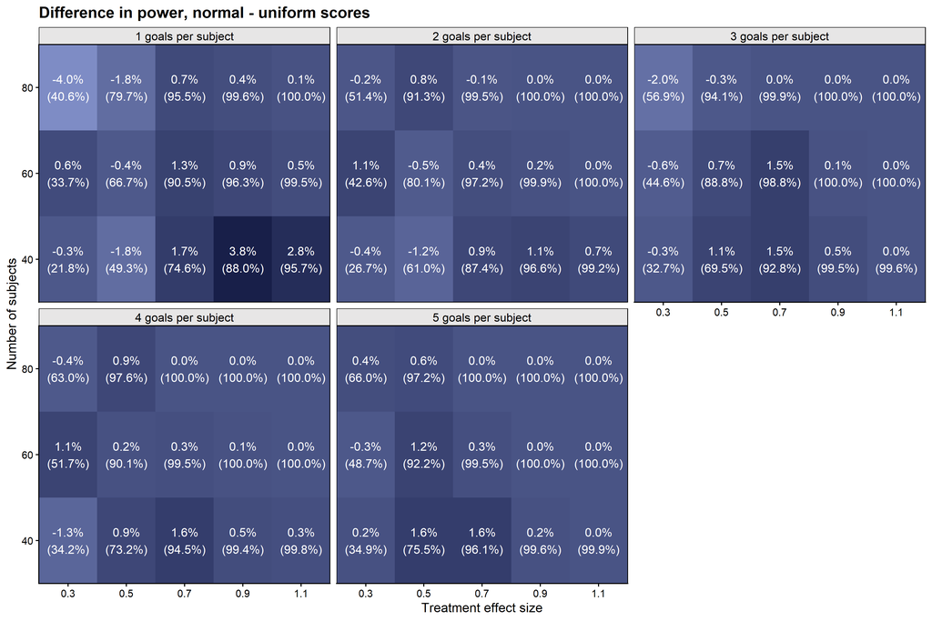

```r
sim_data_power %>%
  filter(summary_score == "tscore") %>%
  select(n_subjects, delta, n_goals, score_dist, power,
         n_subjects_delta, n_subjects_n_goals, n_goals_label) %>%
  pivot_wider(names_from = score_dist, values_from = power) %>%
  rename(power_norm = norm, power_unif = unif) %>%
  mutate(
    power_diff = power_norm - power_unif,
    power_diff_label = glue("{scales::percent(power_diff, accuracy = 0.1)}",
                            "\n({scales::percent(power_norm, accuracy = 0.1)})")
  ) %>%
  ggplot(aes(x = factor(delta), y = factor(n_subjects))) +
  geom_tile(aes(fill = power_diff)) +
  geom_text(aes(label = power_diff_label), color = "white") +
  facet_wrap(~n_goals_label) +
  theme(legend.position = "none") +
  scale_x_discrete("Treatment effect size", expand = c(0, 0)) +
  scale_y_discrete("Number of subjects", expand = c(0, 0)) +
  labs(title = "Difference in power, normal - uniform scores")
```

Compute effect size mean and SE:

```r
sim_data_mean_score_diff_mean_se <-
  sim_data_mean_score_ttest %>%
  filter(stat == "score_diff") %>%
  group_by(n_subjects, delta, n_goals, score_dist) %>%
  summarise(
    n_sim = n(),
    mean_score_diff = mean(-value),
    mean_score_diff_se = mean_score_diff / sqrt(n_sim),
    .groups = "drop"
  ) %>%
  mutate(
    n_subjects_delta = glue("{n_subjects} subjects, delta = {delta}"),
    n_subjects_n_goals = glue("{n_subjects} subjects, ",
                              "{n_goals} goals per subject"),
    n_goals_label = glue("{n_goals} goals per subject"),
    score_dist_label = factor(score_dist, levels = c("norm", "unif"),
                              labels = c("Normal", "Uniform"))
  )
sim_data_tscore_diff_mean_se <-
  sim_data_tscore_ttest %>%
  filter(stat == "tscore_diff") %>%
  group_by(n_subjects, delta, n_goals, score_dist) %>%
  summarise(
    n_sim = n(),
    tscore_diff = mean(-value),
    tscore_diff_se = tscore_diff / sqrt(n_sim),
    .groups = "drop"
  ) %>%
  mutate(
    n_subjects_delta = glue("{n_subjects} subjects, delta = {delta}"),
    n_subjects_n_goals = glue("{n_subjects} subjects, ",
                              "{n_goals} goals per subject"),
    n_goals_label = glue("{n_goals} goals per subject"),
    score_dist_label = factor(score_dist, levels = c("norm", "unif"),
                              labels = c("Normal", "Uniform"))
  )
```

And plot for 60 subjects:

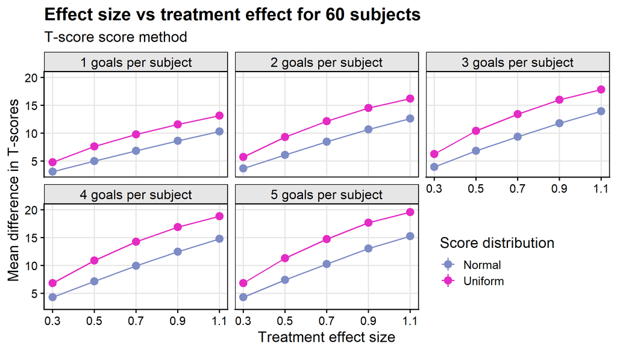

```r
sim_data_tscore_diff_mean_se %>%
  filter(n_subjects == 60) %>%
  ggplot(aes(x = delta, y = tscore_diff, color = score_dist_label)) +
  geom_line() +
  geom_pointrange(aes(ymin = tscore_diff - tscore_diff_se,
                      ymax = tscore_diff + tscore_diff_se)) +
  facet_wrap(~n_goals_label) +
  scale_x_continuous("Treatment effect size",
                     breaks = c(0.3, 0.5, 0.7, 0.9, 1.1)) +
  scale_y_continuous("Mean difference in T-scores") +
  labs(color = "Score distribution",
       title = "Effect size vs treatment effect for 60 subjects",
       subtitle = "T-score score method") +
  theme(legend.position = c(0.7, 0.2))
```

Compute the difference in T-scores for each parameter combination:

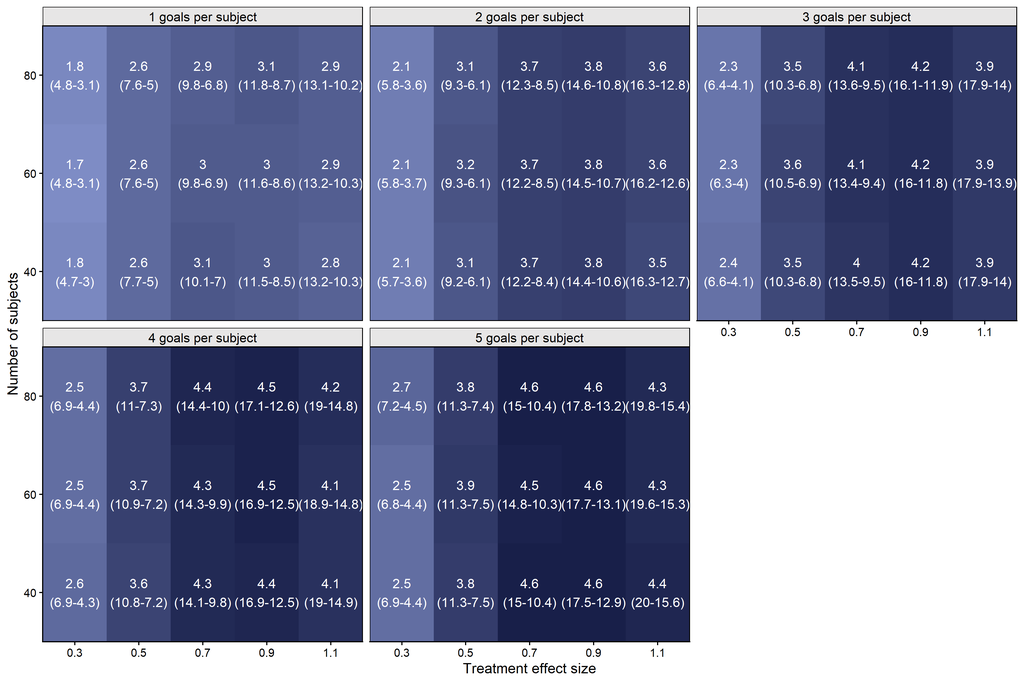

```r
sim_data_tscore_diff_mean_se %>%
  select(n_subjects, delta, n_goals, score_dist, tscore_diff,
         n_subjects_delta, n_subjects_n_goals, n_goals_label) %>%
  pivot_wider(names_from = score_dist, values_from = tscore_diff) %>%
  mutate(
    score_diff_diff = round(unif - norm, 1),
    score_diff_diff_label = glue(
      "{score_diff_diff}\n({round(unif, 1)}-{round(norm, 1)})"
    )
  ) %>%
  ggplot(aes(x = factor(delta), y = factor(n_subjects))) +
  geom_tile(aes(fill = score_diff_diff)) +
  geom_text(aes(label = score_diff_diff_label), color = "white") +
  facet_wrap(~n_goals_label) +
  theme(legend.position = "none") +
  scale_x_discrete("Treatment effect size", expand = c(0, 0)) +
  scale_y_discrete("Number of subjects", expand = c(0, 0))
```

The uniform distribution of scores consistently overestimates the treatment effect, by about 2 to 5 points on the T-score.

What about standardized effect size?

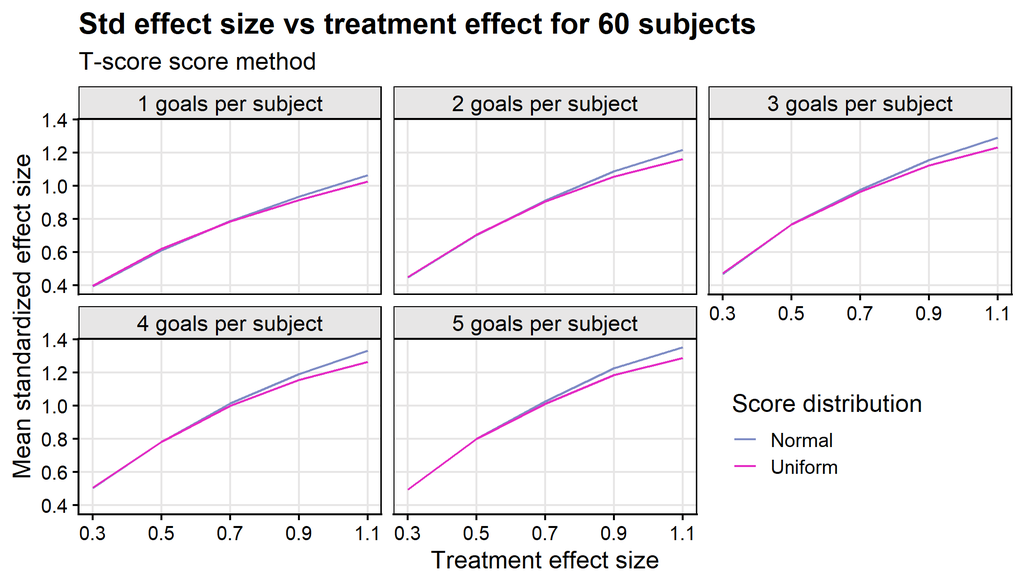

```r
sim_data_tscore_effect_size_summary <-
  sim_data_tscore_effect_size %>%
  group_by(n_subjects, delta, n_goals, score_dist) %>%
  summarise(
    n_sim = n(),
    mean_effect_size = mean(cohen_d),
    sd_effect_size = sd(cohen_d),
    .groups = "drop"
  ) %>%
  mutate(
    n_subjects_delta = glue("{n_subjects} subjects, delta = {delta}"),
    n_subjects_n_goals = glue("{n_subjects} subjects, ",
                              "{n_goals} goals per subject"),
    n_goals_label = glue("{n_goals} goals per subject"),
    score_dist_label = factor(score_dist, levels = c("norm", "unif"),
                              labels = c("Normal", "Uniform"))
  )
sim_data_tscore_effect_size_summary %>%
  filter(n_subjects == 60) %>%
  ggplot(aes(x = delta, y = mean_effect_size, color = score_dist_label)) +
  geom_line() +
  # geom_pointrange(aes(ymin = tscore_diff - tscore_diff_se,
  #                     ymax = tscore_diff + tscore_diff_se)) +
  facet_wrap(~n_goals_label) +
  scale_x_continuous("Treatment effect size",
                     breaks = c(0.3, 0.5, 0.7, 0.9, 1.1)) +
  scale_y_continuous("Mean standardized effect size") +
  labs(color = "Score distribution",
       title = "Std effect size vs treatment effect for 60 subjects",
       subtitle = "T-score score method") +
  theme(legend.position = c(0.7, 0.2))
```

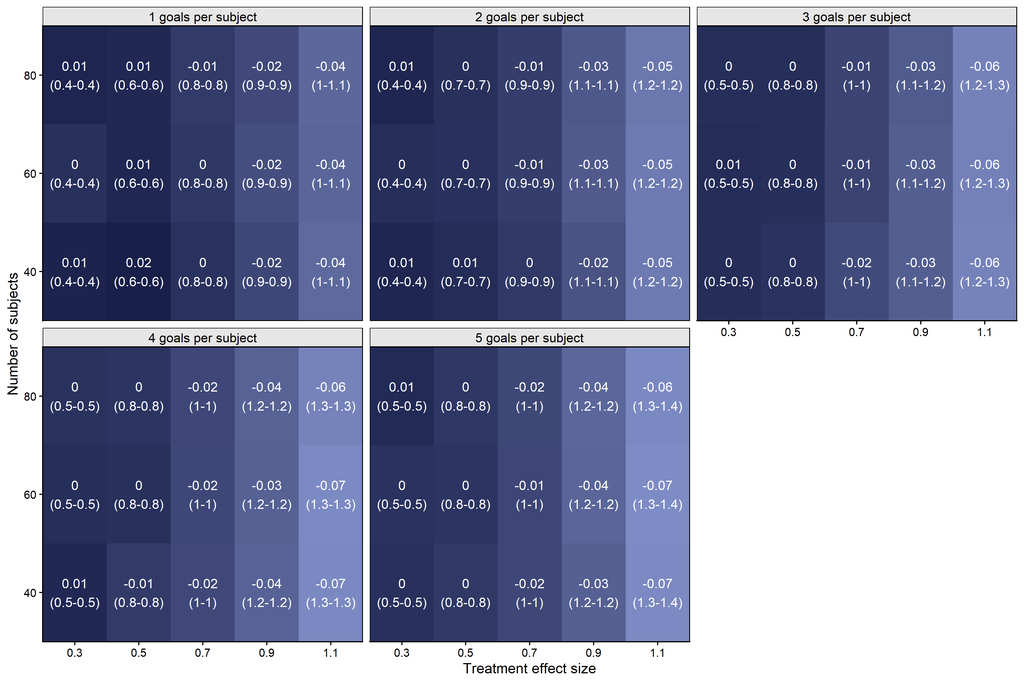

```r
sim_data_tscore_effect_size_summary %>%
  select(n_subjects, delta, n_goals, score_dist, mean_effect_size,
         n_subjects_delta, n_subjects_n_goals, n_goals_label) %>%
  pivot_wider(names_from = score_dist, values_from = mean_effect_size) %>%
  mutate(
    effect_size_diff = unif - norm,
    effect_size_diff_label = glue(
      "{round(effect_size_diff, 2)}\n({round(unif, 1)}-{round(norm, 1)})"
    )
  ) %>%
  ggplot(aes(x = factor(delta), y = factor(n_subjects))) +
  geom_tile(aes(fill = effect_size_diff)) +
  geom_text(aes(label = effect_size_diff_label), color = "white") +
  facet_wrap(~n_goals_label) +
  theme(legend.position = "none") +
  scale_x_discrete("Treatment effect size", expand = c(0, 0)) +
  scale_y_discrete("Number of subjects", expand = c(0, 0))
```

# Reproducibility

**Reproducibility receipt**

```r
Sys.time()
```

```
## [1] "2021-06-21 14:01:09 AST"
```

```r
if ("git2r" %in% installed.packages()) {
  if (git2r::in_repository()) {
    git2r::repository()
  }
}
```

```
## Local:    main G:/My Drive/gas-simulations/ispor-europe2021-gas-sim
## Remote:   main @ origin (https://github.com/taylordunn/ispor-europe2021-gas-sim)
## Head:     [bfefc81] 2021-06-14: Started writing exploratory notebook and abstract
```

# References

Urach, S, CMW Gaasterland, M Posch, B Jilma, K Roes, G Rosenkranz, JH Van der Lee, and R Ristl. 2019. “Statistical analysis of Goal Attainment Scaling endpoints in randomised trials.” *Statistical Methods in Medical Research* 28 (6): 1893–1910. https://doi.org/10.1177/0962280218777896.